# Anemia in Senegal: The 2008 World Food Price Crisis

Jesse McDevitt-Irwin

# Summary

I will explore the effect of the 208 world food price crisis on the health of Senegalese children who were in-utero at the time. I predict that the 2008 crisis had a negative impact on fetal health, and that its effect was diminishing with distance from Dakar, the port and economic hub of Senegal. Conceptually, I will compare the hemoglobin of children born just before or conceived just after the crisis, to those who were exposed in-utero.

While previous work has explored the effect of the 2008 crisis on child health, mine will be the first to use a fetal origins approach, which allows data collected several years after the crisis to be used in analysis. With this increased variation, I will test the hypothesis that the crisis had a stronger effect in areas more closely connected to the world market (e.g. Dakar) than in more isolated areas.

I find no evidence that distance to Dakar mediates the relationship between in-utero exposure to the 2008 crisis and hemoglobin 2-4 years later. As this was the original hypothesis, the following findings should be viewed skeptically, more as suggestions for future research than as definitive evidence.

I do find suggestive evidence that Dakar felt the strongest impact of the crisis, that urban dwellers suffered more than rural dwellers and that the observed effect of the shock was smaller 4 years later than 2 years later. My results support the existing hypothesis in the food-policy literature, that urban dwellers are more vulnerable than rural dwellers to increases in food prices.

# Introduction

After an extended period of low and stable food prices, in early 2008 world food prices increased dramatically. The causes are debated, but include American agriculture policy as well as financial speculation (Rosset 2008). The prices of both rice and wheat doubled in fewer than 6 months, while the prices of other staples increased as well. This increase lead to riots and unrest in low to medium-income countries around the world, including Senegal.

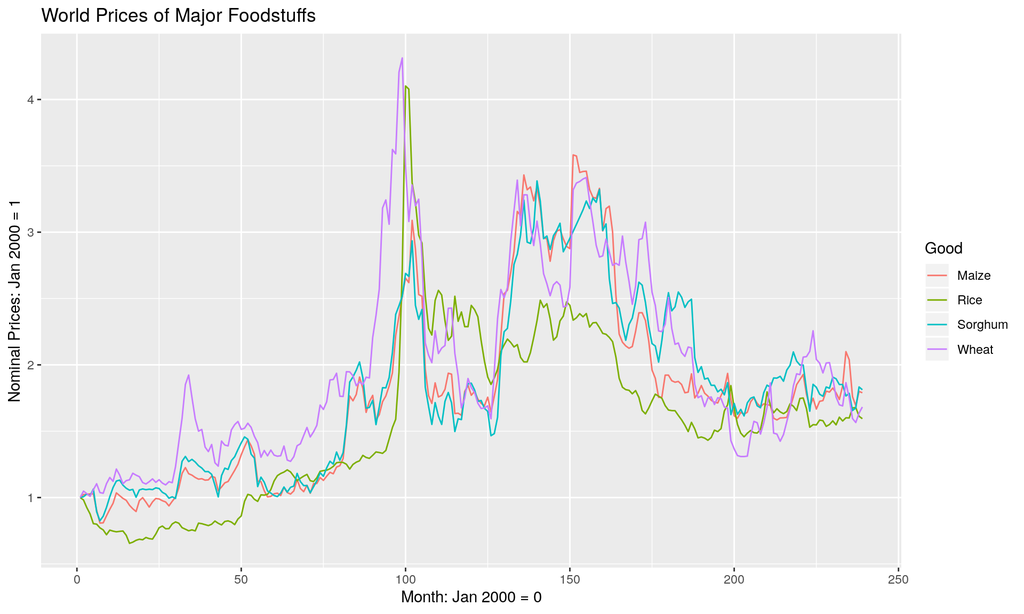

The world price spike is apparent in retail prices in Senegal. Here I plot the retail price of rice in Dakar. Rice prices follow a similar pattern to the world price, with a delay, shifted upwards by transportation costs and retail markup.

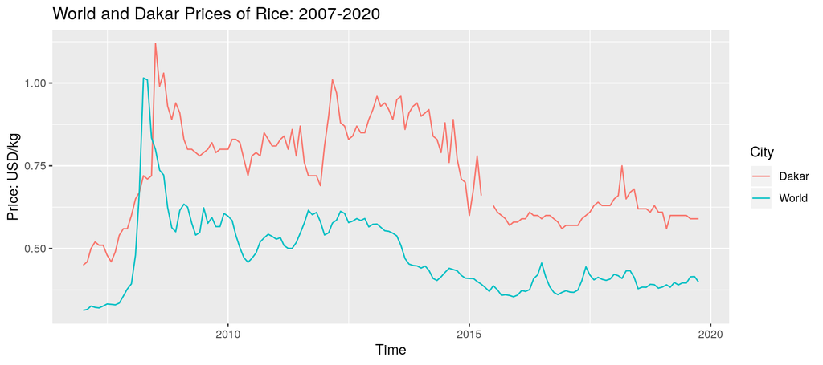

The 2008 crisis drew attention from the fields of peasant studies, nutrition, and development, as well as from Science and Nature.[^1] The crisis was viewed as evidence of the risk poor countries take on by specializing in cash-crops for export and relying on imported food. Much of the rhetoric in these fields advocates for reduced integration into the world market, and more self-sufficiency in food production (Rosset 2008).

As emphasized by Sen (1980), food security depends on the combination of level and volatility of food entitlements. From the simplest model of comparative advantage, we know that trade will induce specialization. This specialization will increase average incomes, but the effect of specialization and trade on volatility is unresolved (Giovanni and Levchenko 2009; Burgess and Donaldson 2010).

Existing studies in economics explore the effect of the 2008 crisis on health and welfare (Arndt et al. 2016; Dimova and Gbakou 2013a). Dimova et. al. estimate welfare elasticity with respect to price in Cote d’Ivoire during the crisis and argue that the majority of rural dwellers actually benefited from the shock, while urban dwellers suffered. Arndt et. al. take a more similar approach to mine, looking at the effect of high food prices on child weight-for-height. The authors find that weight-for-height was negatively correlated with food price increases, but study is limited by its dataset, which relies on direct observation during and after the crisis.

Using a fetal origins approach opens a wider range of evidence, as data from 2-4 years post-crisis can be used. Having a broader sample allows me to disentangle the effect of the crisis from seasonal fluctuations, unlike Arndt et. al. (2016). By looking at hemoglobin, I gain improved sensitivity relative to weight-for-height, as hemoglobin is sensitive to both quality and quantity of food, unlike weight-for-height. Relative to Dimova et. al., my approach measures the direct effect of the 2008 crisis on maternal and fetal health, rather than a synthetic measure of welfare.

Moreover, the increased variation from the fetal origins approach allows me to test for spatial heterogeneity in the effect of the crisis. This will allow me to provide econometric evidence towards the discussion being held in adjacent fields about market integration and food sovereignty. Previous work has emphasized a rural-urban divide, with the urban poor suffering from increased food prices, and the rural poor minimally affected (Dimova and Gbakou 2013b; Barrett 2010; Ruel et al. 2009). While it is true that rural-dwellers are more likely to be net food-sellers, this hypothesis overlooks the broad class of rural poor who are net food-consumers. I will be able to test both this rural-urban hypothesis, and my own distance hypothesis.

## The Economy of Senegal: Food and Trade

Although agriculture is the primary means of livelihood for 69% of the population, imports make up a large part of the food supply. The main staples are rice, maize, sorghum, wheat and millet. As seen in the graph below, foods which are mainly imported, like wheat and rice, have increased in importance in Senegal over the past thirty years, while locally produced staples millet and sorghum have declined in per-capita consumption.

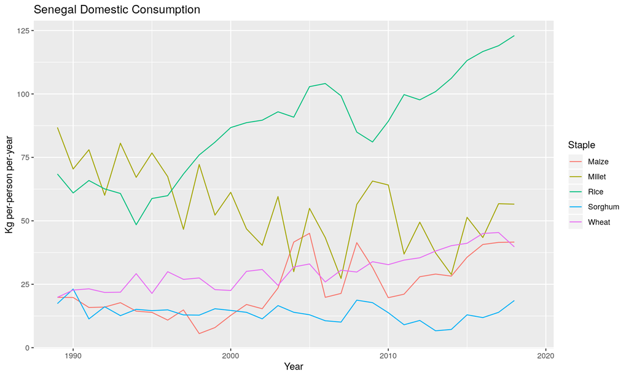

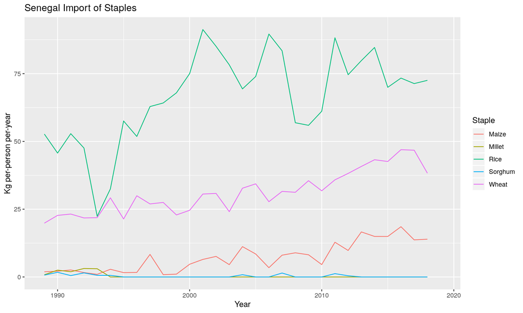

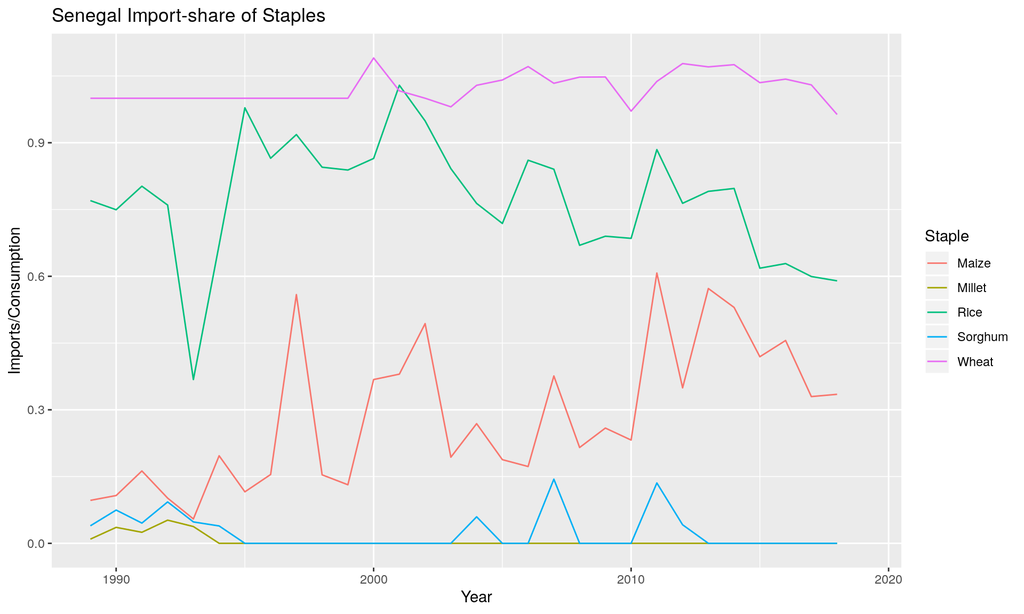

We see that in 2008, when prices increased dramatically, consumption of millet and sorghum increased while that of rice decreased. This might reflect some substitution away from high-priced, imported goods. It would indicate some reserve capacity for local food production.

To construct a world price index that is relevant for anemia in Senegal, I use two weights. One, the amount of consumption of a particular staple in Senegal in 2008, and two, the iron per 100 grams of that staple.[^2] I took the weighted average of the commodity prices in real USD, and multiplied by the CFA-USD exchange rate in order to get prices in terms of local currency. I plot the index in log-terms below, so that proportional changes can be easily read.

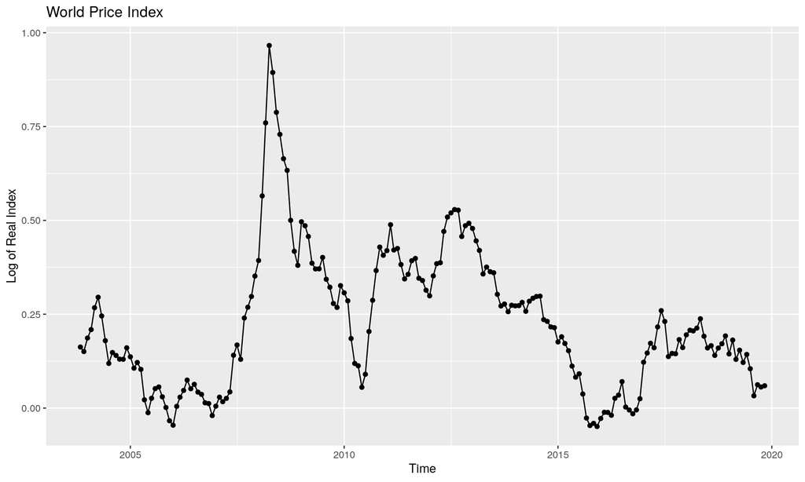

## World Price, Local Price and Transportation Costs

The effect of world price on local price will depend on transportation costs and local supply (Minot 2010). Consider a simple model. $P_a$ is the price in autarky and is determined via local supply and demand. Because Senegal is an small-open-economy (SOE), trade provides an infinitely elastic supply curve at price $P_w +t$, the world price plus transportation costs. Given an increase in the world price of food, there are three cases for how the local price will respond:

1. Food was not imported before the price increase, and it is not be imported after the increase. Price will be determined by local supply and demand, $\frac{\Delta P_l}{\Delta P_w} = 0$.
2. Food was imported before the price increase, but is not imported afterwards. In this case, the local supply and demand curves meet at a lower price than $P_w$. The economy moves up the local supply curve and $0 < \frac{\Delta P_l}{\Delta P_w} < 1$.
3. Food was imported before the price increase, and continues to be imported afterwards. In this case, the new price is still $P_w + t$ and $\frac{\Delta P_l}{\Delta P_w} = 1$.

Transportation costs also change the relative price of commodities faced by producers, affecting investment. Transportation costs make commercial, export-oriented production less profitable relative to local, subsistence production. Thus, we should also expect food-producing capacity to increase with transportation costs. Greater food-producing capacity would shift the local supply curve outward, making the world price less likely to bind.

# Price and Consumption

As price increases there are substitution and income effects which lead to lower consumption. Given that the 2008 price increase affected all of the major, imported staples, I would expect the substitution effect to be relatively small.[^3] As poor families spend a greater share of income on food than rich families, the income effect, and therefore total impact of the spike, should decrease with household wealth.

Iron, unlike calories, is a function of both food quality and quantity. As prices increase, the household must either reduce quantity or change the type of food they are consuming. In Burkina Faso, which neighbors Senegal, the 2008 price shock lead to decreased amounts and diversity of food (Martin-Prevel et al. 2012). As I am particularly interested in female iron consumption, gender inequality looms large. While there are a host of issues surrounding intra-household allocation and gender, I will not treat those in this paper. Instead, I will assume that female iron consumption decreases with prices in a similar way as household iron consumption.

Given a price shock, households will try to smooth consumption across time, attenuating the effect of price on consumption. However, most households, especially the poor, are credit constrained. Thus, we would expect a nonlinear effect of price on consumption, with large increases in price having disproportionately large effect on consumption. As savings, and therefore ability to smooth in a credit-constrained world, are a stock, prices in previous months will also affect the ability to smooth consumption. If prices have been high for several months, then a household is less likely to be able to smooth consumption given another month of high prices.

# Iron and Anemia in Mother and Child

Anemia is characterized by low levels of hemoglobin in the blood and can be caused by deficiencies in iron, folate and other micro-nutrients. By latest estimates, 1.2 billion people around the world suffer from iron deficiency anemia. Iron-deficiency anemia causes fatigue and impairs cognitive and motor development. Anemia is a health concern across the income spectrum, but is more prevalent among the poor. Iron availability depends on food intake, both quantity and quality. Absorption of heme-iron (animal-based) is greater than absorption of plant-based iron. In a healthy person, there are iron-stores about equal to the amount of iron in use in the person’s blood. There is a small, constant loss of iron. The bioavailability of iron for a person is a stock, while iron intake is a flow, meaning that past iron consumption will affect current availability (Camaschella 2015).

Iron is important for both maternal and fetal health. For the mother, anemia makes complications (and death) from birth more likely. Iron is passed from the mother to fetus, allowing the development of fetal hemoglobin, which differs from adult hemoglobin. Over the first four months, the infant breaks down the fetal hemoglobin and synthesizes adult hemoglobin. Little iron is transmitted through breast-milk, so the fetus must develop sufficient stores of iron in order to make the transition from fetal to adult hemoglobin as they grow and their blood volume increases. The estimated iron requirement for pregnancy is 1,000 mg– nearly half of the total iron store in a healthy, non-pregnant woman (Lactation 1990).

Maternal anemia then has a direct effect on infant anemia, as the fetus cannot make adequate stores to last the breast-feeding period. Unless remedied through increased iron consumption, anemia will remain as the infant grows into a child. During menarche, iron requirements increase for girls, and many become anemic. Thus an anemic mother begets anemic child who becomes an anemic woman who begets an anemic child. This inter-generational aspect of anemia is well appreciated by the WHO and is recognized as an important issue at the nexus of public health, nutrition and female empowerment.

# Data

The DHS measures the hemoglobin of infants and children from age 6 months to 5 years. There are two DHS surveys of Senegal, 2010 and 2012, which include children in-utero during the 2008 crisis. The DHS data includes location and households characteristics.

At birth, the infant has a large amount of fetal hemoglobin which must be broken down and replaced by adult hemoglobin. In general, hemoglobin levels decrease from birth until 6 months to 2 years, then they begin to increase again. We see such a pattern in the DHS data, which I plot below. The yellow window indicates the 2008 crisis.

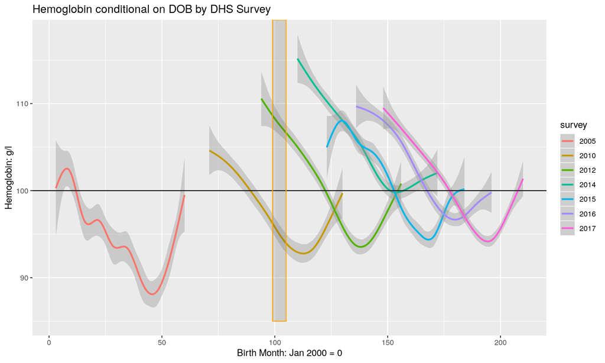

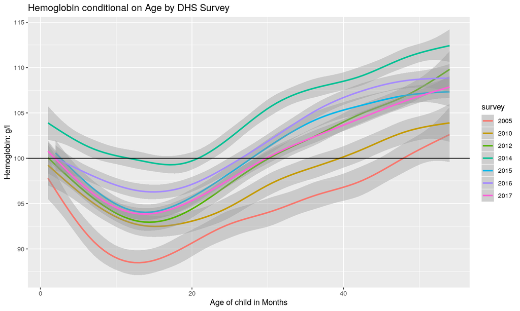

Anemia is relatively rare in children, compared to in infants. Anemia resurges in girls upon menarche. The cutoff for anemia in adults, 100 grams per liter of blood is shown as a black, horizontal line.

In order to account for age, I will use a z-score approach analogous to how child height and weight is treated by the DHS. We are interested in the 2008 price shock. The only surveys which provide information on the shock are 2010 and 2012, so I use the other 5 surveys (2005, 2014-17) to make z-scores for the surveys of interest. Taking the mean and standard deviation by age, I then normalize hemoglobin by age.

# Variables

Drawing on the sections above, I will use several variables for my analysis:

- Hemoglobin-for-age: the hemoglobin of a child minus the mean and divided by the standard deviation hemoglobin for the age of the child;
- Wealth: an index, calculated by the DHS as a combination of goods which the household owns; and,
- Distance to Dakar: the driving distance from each DHS cluster to Dakar, calculated via the Open Street Maps API.

The effect of distance will be flexible for the Casamance region, which although physically close to Dakar, is separated by The Gambia.

# Methodology

One potential route would be to regress child hemoglobin on world prices during gestation. This approach is complicated by the fact that prices during gestation are a distribution, not a value. The relationship between monthly price and hemoglobin will likely be non-linear, as households are able to smooth small price changes, but not large increases. We could capture this non-linear relationship using a “bin” approach. First we would discretize the problem, breaking up price into $n$ bins. Then we would count the number of months each child spent in each price-bin over the course of gestation.

However, this approach assumes that the timing of price is irrelevant. Given that different stages of pregnancy have very different iron requirements, the timing of price, not only the level each month, is important. Second, because of credit-constraints, a month of high prices will be harder on a household if it falls after another month of high prices than after a month of low prices. Third, because prices affect iron intake, a flow, but hemoglobin is determined by iron stocks, we would expect persistent effects over time.

Because of this complexity, and the fact that the 2008 crisis dominates variation over the period of study, I will instead concentrate on a single period of unusually high prices. I will construct the proper control group based on knowledge about the biological process of hemoglobin formation. Doing this will also allow me to speak directly to a substantial literature which is interested in effects of the 2008 crisis.

The 2008 crisis forms a contiguous 8-month period in which the price index is greater than at any other point in the 20 year span. I will take all those in-utero during this period, February to September 2008, to be exposed. The degree of exposure will be the sum of months in-utero during the crisis period, weighted by the price index. For anyone born before March 2008, or conceived after September 2008, the in-utero exposure will be zero. For someone born in November 2008, the exposure measure would be 1, as they were in-utero for the entirety of the crisis period.

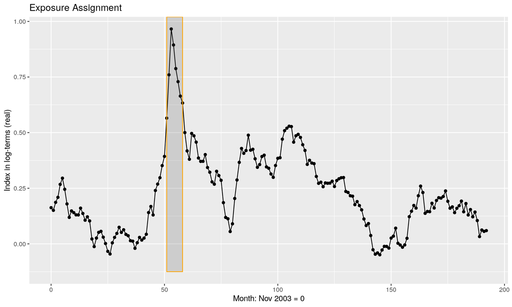

I present two kinds of evidence:

1. The deviation from a quadratic time trend of the exposed cohorts, estimated separately by survey; and,
2. The median hemoglobin-for-age by birth-quarter.

I use median-regression, rather than least-squares, as it is less sensitive to outliers. The identification hinges on exposure being orthogonal to other determinants of hemoglobin. The regression is as follows:
$$H_i = \alpha_0 + \beta Exp_i + \delta Exp_i*Dist_i + \alpha_1MOB + \alpha_2MOB^2$$

where $H_i$ is hemoglobin-for-age, $Exp_i$ is the number of months in-utero during the crisis, $Dist_i$ is the driving time to Dakar for the cluster of individual $i$. My hypotheses are that $\beta <0$ and $\delta > 0$. I will also estimate a more complex relationship, in order to test the distance hypothesis next to the urban-rural hypothesis discussed above, in order to speak to the broader literature:

$$H_i = \alpha_0 + \beta Exp_i + \delta Exp_i*Dist_i + \alpha_1MOB + \alpha_2MOB^2+ \gamma Exp_i * Urban_i + \rho Exp_i*Wealth + \alpha_3 Dist_i + \alpha_4 Urban_i + \alpha_5 Wealth$$
I predict $\rho >0$. From the previous literature, one would expect $\gamma >0$.

# Results

Here I plot the median hemoglobin by birth-quarter. I highlight the two quarters which are exposed to the 2008 crisis in-utero. First, I present the data for all of Senegal. A generous soul might see the expected dip during the crisis, but the result is not obvious. Second, I plot the data for Dakar. According to my predictions, this should be where the dip is most obvious. Again, if you squint and wish with all your heart, you can see the expected dip. Third, I present the data for Kolda, a region to the southeast of Dakar, relatively isolated and with significant food production. I would not expect to see much of a dip here, and no dip is evident.

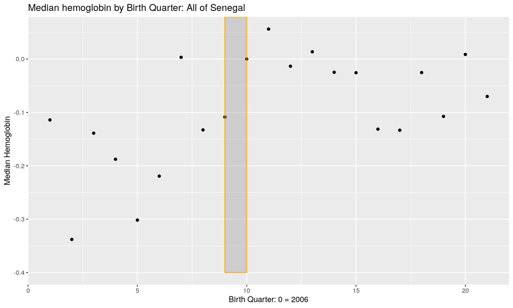

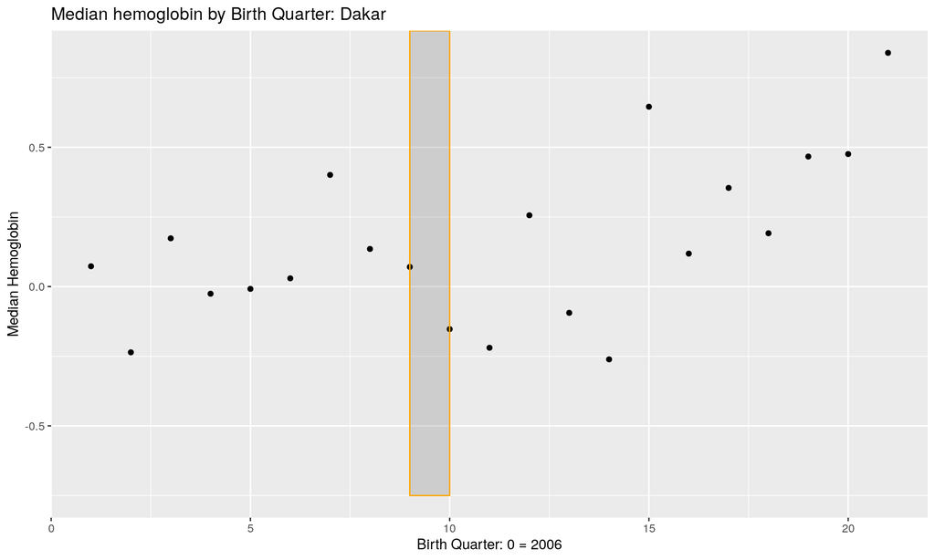

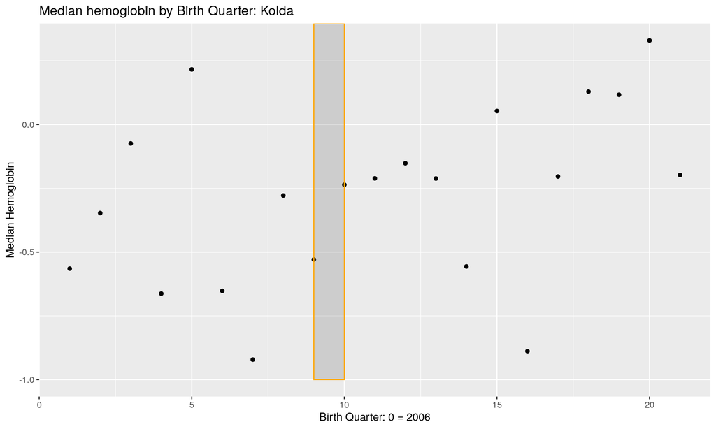

This evidence is suggestive, but unclear. It is clear that the effect of the 2008 crisis was not large, in the sense of being easily discernible.

Next I allow the effect of the crisis to vary by region. I report the interaction term for each region below (Dakar is the left-out group):

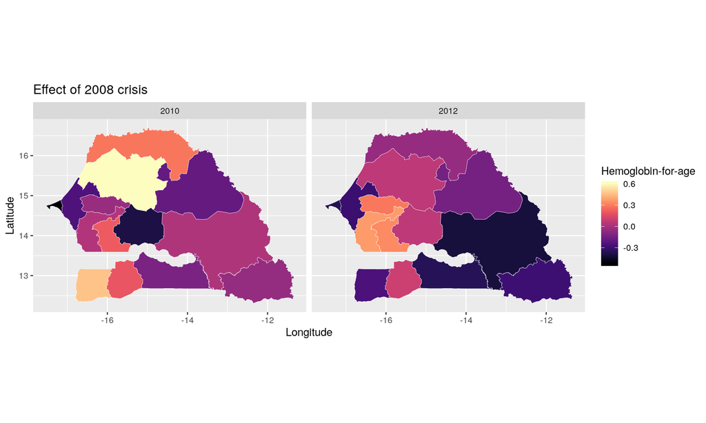

# Discussion

Because of the fetal origins approach, where we implicitly compare those in-utero and those already born, we can safely infer that any estimated effect reflects a change in in-utero health conditions. However, the crisis was more than just an increase in prices. During the crisis there were protests, unrest and a change in the type of agricultural production, with an increase in staples like millet and sorghum. Thus, we cannot rule out that the estimated effect of the crisis has more to do with the general characteristics of the period than with prices *per se*. For example, the strong effect in Dakar might come from social unrest, as there was rioting in Dakar during the period.

My results support the existing view of the food policy literature (Cohen and Garrett 2010; Dimova and Gbakou 2013b) that urban households are negatively affected increases in food prices while the effect on the rural populace is minimal.

The attenuation of my results may be due to substitution towards locally produced millet. This would indicate that reserve capacity for food production is an important safety net for commercializing nations.

# Conclusion

# References

Arndt, Channing, M. Azhar Hussain, Vincenzo Salvucci, and Lars Peter Østerdal. 2016. “Effects of Food Price Shocks on Child Malnutrition: The Mozambican Experience 2008/2009.” *Economics & Human Biology* 22: 1–13.

Barrett, Christopher B. 2010. “Measuring Food Insecurity.” *Science* 327 (5967): 825–28.

Burgess, Robin, and Dave Donaldson. 2010. “Can Openness Mitigate the Effects of Weather Shocks? Evidence from India’s Famine Era.” *American Economic Review* 100 (2): 449–53.

Camaschella, Clara. 2015. “Iron-Deficiency Anemia.” *New England Journal of Medicine* 372 (19): 1832–43.

Cohen, Marc J., and James L. Garrett. 2010. “The Food Price Crisis and Urban Food (in) Security.” *Environment and Urbanization* 22 (2): 467–82.

Dimova, Ralitza, and Monnet Gbakou. 2013a. “The Global Food Crisis: Disaster, Opportunity or Non-Event? Household Level Evidence from Côte d’Ivoire.” *World Development* 46: 185–96.

———. 2013b. “The Global Food Crisis: Disaster, Opportunity or Non-Event? Household Level Evidence from Côte d’Ivoire.” *World Development* 46: 185–96.

Giovanni, Julian di, and Andrei A. Levchenko. 2009. “Trade Openness and Volatility.” *The Review of Economics and Statistics* 91 (3): 558–85.

Hadley, Craig, Drew A. Linzer, Tefera Belachew, Abebe Gebre Mariam, Fasil Tessema, and David Lindstrom. 2011. “Household Capacities, Vulnerabilities and Food Insecurity: Shifts in Food Insecurity in Urban and Rural Ethiopia During the 2008 Food Crisis.” *Social Science & Medicine (1982)* 73 (10): 1534–42. doi:10.1016/j.socscimed.2011.09.004.

Hossain, Naomi, and Devangana Kalita. 2014. “Moral Economy in a Global Era: The Politics of Provisions During Contemporary Food Price Spikes.” *The Journal of Peasant Studies* 41 (5): 815–31. doi:10.1080/03066150.2014.895328.

Lactation, Institute of Medicine (US) Committee on Nutritional Status During Pregnancy and. 1990. *Iron Nutrition During Pregnancy*. National Academies Press (US).

Mané, N. Binta, Kirsten B. Simondon, Aldiouma Diallo, Adama M. Marra, and François Simondon. 2006. “Early Breastfeeding Cessation in Rural Senegal: Causes, Modes, and Consequences.” *American Journal of Public Health* 96 (1): 139–44.

Martin-Prevel, Yves, Elodie Becquey, Sylvestre Tapsoba, Florence Castan, Dramane Coulibaly, Sonia Fortin, Mahama Zoungrana, Matthias Lange, Francis Delpeuch, and Mathilde Savy. 2012. “The 2008 Food Price Crisis Negatively Affected Household Food Security and Dietary Diversity in Urban Burkina Faso.” *The Journal of Nutrition* 142 (9): 1748–55. doi:10.3945/jn.112.159996.

Minot, Nicholas. 2010. *Transmission of World Food Price Changes to Markets in Sub-Saharan Africa*. International Food Policy Research Institute Washington.

Neville, Margaret C., Ronald Keller, Joy Seacat, Valerie Lutes, Marianne Neifert, Clare Casey, Jonathan Allen, and Philip Archer. 1988. “Studies in Human Lactation: Milk Volumes in Lactating Women During the Onset of Lactation and Full Lactation.” *The American Journal of Clinical Nutrition* 48 (6): 1375–86.

Rosset, Peter. 2008. “Food Sovereignty and the Contemporary Food Crisis.” *Development* 51 (4): 460–63.

Ruel, Marie T., James L. Garrett, Corinna Hawkes, and Marc J. Cohen. 2009. “The Food, Fuel, and Financial Crises Affect the Urban and Rural Poor Disproportionately: A Review of the Evidence.” *The Journal of Nutrition* 140 (1): 170S–176S.

Sen, Amartya. 1981. “Ingredients of Famine Analysis: Availability and Entitlements.” *The Quarterly Journal of Economics* 96 (3): 433–64.

Von Braun, Joachim. 2008. “The Food Crisis Isn’t over.” *Nature* 456 (7223): 701.

Wodon, Quentin, and Hassan Zaman. 2008. *Rising Food Prices in Sub-Saharan Africa: Poverty Impact and Policy Responses*. Policy Research Working Papers. The World Bank. doi:10.1596/1813-9450-4738.

[^1]: See Cohen and Garrett (2010); Hadley et al. (2011); Martin-Prevel et al. (2012); Minot (2010); Ruel et al. (2009); Wodon and Zaman (2008); Von Braun (2008); Barrett (2010).
[^2]: The final weights were 0.39 0.13 0.18 0.30 for rice, maize, sorghum and wheat respectively. I exclude millet from the study because it has not been imported or exported since the early 1990’s.
[^3]: One possibility is that the increase in the price of imported goods lead to increased consumption of local crops, like millet. Millet is relatively high in iron compared to rice, so this would attenuate any results I find.
[^4]: Note that this all relies on women breastfeeding their children. In Senegal, breastfeeding is overwhelmingly common during the first six months, with very little cessation before the child reaches a year old (Mané et al. 2006).